# Reproducing the figures of Hévin et al.

Matthieu Wilhelm

2024-11-05

We first load and preprocess the data and as well as import the package [`metacoder`](https://github.com/grunwaldlab/metacoder).

```r
source("Load_preprocess_sour_rot.R")
library(metacoder)


lsSourRot <- LoadSourRot(normalization = FALSE)
dfSourRot <- lsSourRot$dfSourRot
vars <- lsSourRot$vars
types <- lsSourRot$types

rm(lsSourRot)
```

We first show the number of samples for each modality.

```r
types_names <- c("extern" = "healthy berries", "insect" = "Drosophilia suzuki", "sour rot" = "Sour rot affected berries")
samp_sizes <- table(types)
names(samp_sizes) <- types_names
as.data.frame(samp_sizes) |> rename(Modality = Var1, "Sample size" = Freq) |> knitr::kable()
```

| Modality | Sample size |
| --- | --- |
| healthy berries | 40 |
| Drosophilia suzuki | 18 |
| Sour rot affected berries | 66 |

Then, we create an object that can be parsed by the utilities of `metacoder`. It essentially follows the steps described in the [documentation](https://grunwaldlab.github.io/metacoder_documentation/index.html) of the package.

```r
# creates a column that contains taxonomic information
dfSourRot$lineage <- apply(data.frame(root = "r__Root",apply(dfSourRot[,1:4], 1, function(z)paste(c("s__","g__", "f__", "o__" ),z, sep="") ) |> t())
                             ,1, paste0, collapse= ";")


obj <- parse_tax_data(dfSourRot[, -c(1:4)], # we do not consider the columns corresponding to species, genus, family and order
                      class_cols = "lineage", # the column that contains taxonomic information
                      class_sep = ";", # The character used to separate taxa in the classification
                      class_regex = "^(.+)__(.+)$", # Regex identifying where the data for each taxon is
                      class_key = c(tax_rank = "info", # A key describing each regex capture group
                                    tax_name = "taxon_name"))
```

#### Abundance

First, we briefly explore the number of hits for each sample and each modality.

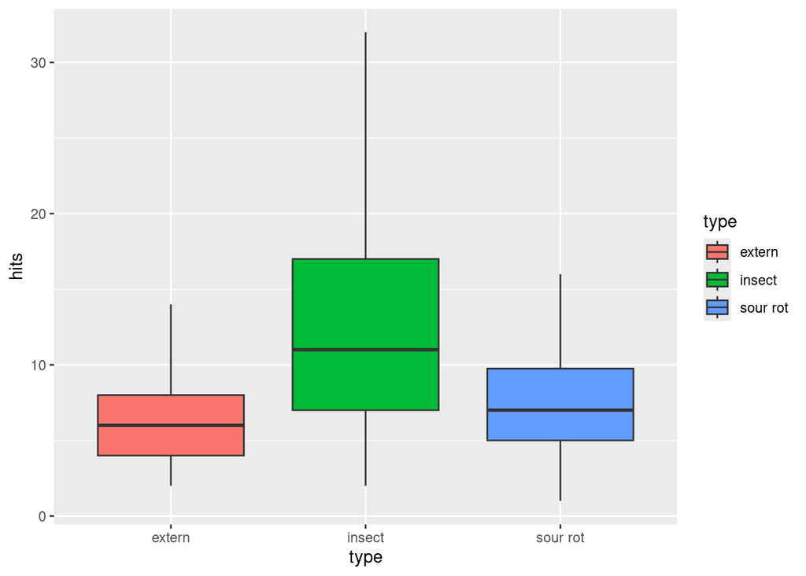

```r
samp_indices <- lapply(dfSourRot, is.numeric) |> unlist()
sample_hits <- cbind.data.frame(colSums(dfSourRot[,samp_indices]), types)
names(sample_hits) <- c("hits", "type")

ggplot(sample_hits, mapping = aes(y = hits, x = type, fill = type)) +
    geom_boxplot()
```

We then compute the necessary tables that will then be used to display the absolute counts of each ITS. This is intrisically not normalized and comparison must be done with care. Indeed, by simply sampling more in one of the group would result in an imbalance in terms of counts, which may or may not be related to a difference in the distribution of the species in the various groups.

```r
obj$data$tax_abund <- calc_taxon_abund(obj, "tax_data", cols = vars)
```

```
## Summing per-taxon counts from 124 columns for 200 taxa
```

```r
obj$data$tax_occ <- calc_n_samples(obj, "tax_abund", groups = types, cols = vars)
```

```
## Calculating number of samples with a value greater than 0 for 124 columns in 3 groups for 200 observations
```

```r
## computes the range of occurences. There is certainly a more efficient way to do it...
range_col <- obj$data$tax_occ |>
  select(-taxon_id) |>
  lapply( FUN = range) |>
  do.call(args = _ , rbind) |>
  as.data.frame() |>
  summarise(Min = min(V1), Max = max(V2)) |>
  unlist()
```

We then plots three heat trees that reflect the abundance. In this first three plots, we use the same color scale to allow for a comparison between the various counts. Note however that this must be done with care. Note that these plots are then also saved in a pdf file.

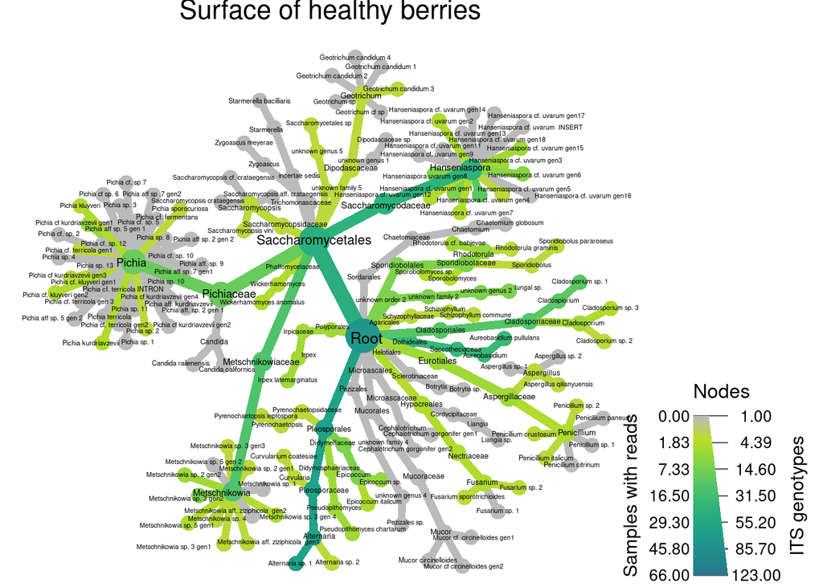

```r
 set.seed(1) # This makes the plot appear the same each time it is run
  heat_tree(obj,
            node_label = taxon_names,
            node_size = n_obs,
            node_color = extern,
            title = "Surface of healthy berries",
            title_size = 0.04,
            node_size_axis_label = "ITS genotypes",
            node_color_axis_label = "Samples with reads",
            layout = "davidson-harel", # The primary layout algorithm
            initial_layout = "reingold-tilford",
            edge_color_interval =  range_col,
            output_file = paste0("Figures/heat_tree_extern", ext))
```

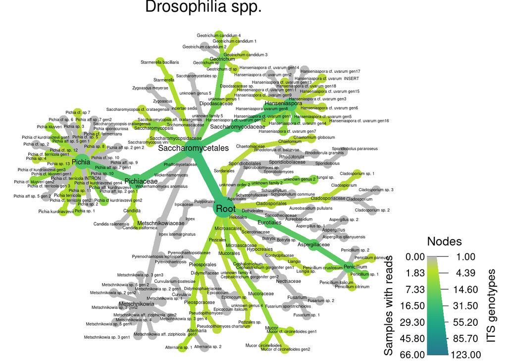

```r
  set.seed(1) # This makes the plot appear the same each time it is run
  heat_tree(obj,
            node_label = taxon_names,
            node_size = n_obs,
            node_color = insect,
            title = "Drosophilia spp.",
            title_size = 0.04,
            node_size_axis_label = "ITS genotypes",
            node_color_axis_label = "Samples with reads",
            layout = "davidson-harel", # The primary layout algorithm
            initial_layout = "reingold-tilford",
            edge_color_interval =  range_col,
            output_file = paste0("Figures/heat_tree_insect", ext))
```

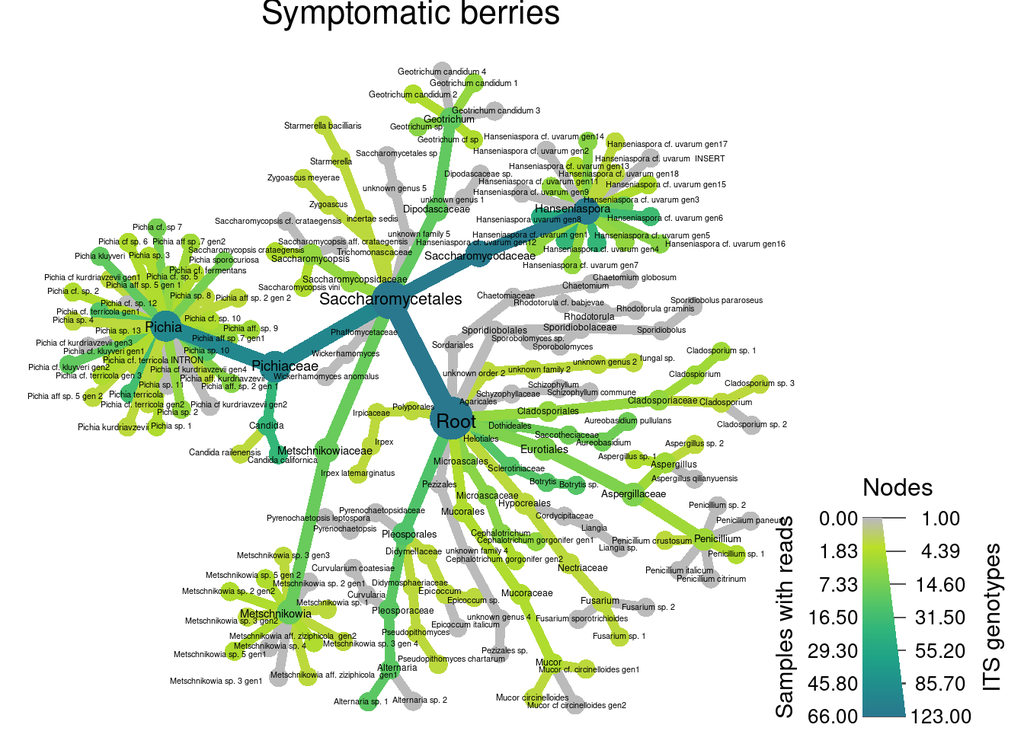

```r
  set.seed(1) # This makes the plot appear the same each time it is run
  heat_tree(obj,
            node_label = taxon_names,
            node_size = n_obs,
            node_color = obj$data$tax_occ$`sour rot`,
            title = "Symptomatic berries",
            title_size = 0.04,
            node_size_axis_label = "ITS genotypes",
            node_color_axis_label = "Samples with reads",
            layout = "davidson-harel", # The primary layout algorithm
            initial_layout = "reingold-tilford",
            edge_color_interval =  range_col,
            output_file = paste0("Figures/heat_tree_sour_rot", ext))
```

The next three plots are the exact same, but without a common color scale. This allows one for an interpretation tailored to the group.

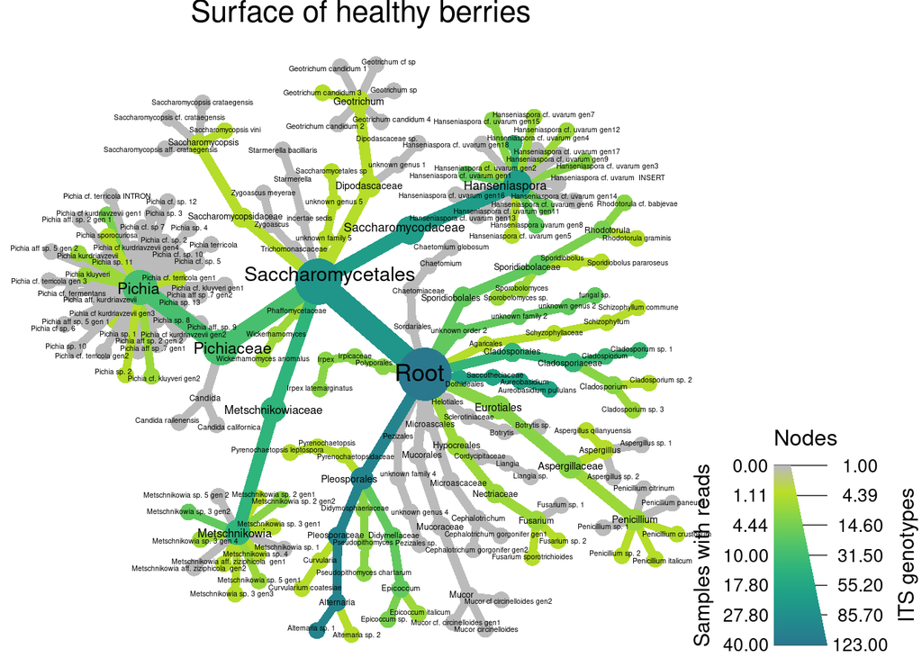

```r
  heat_tree(obj,
            node_label = taxon_names,
            node_size = n_obs,
            node_color = extern,
            title_size = 0.04,
            title = "Surface of healthy berries",
            node_size_axis_label = "ITS genotypes",
            node_color_axis_label = "Samples with reads",
            layout = "davidson-harel", # The primary layout algorithm
            initial_layout = "reingold-tilford",
            output_file = paste0("Figures/heat_tree_extern_ownscale", ext))
```

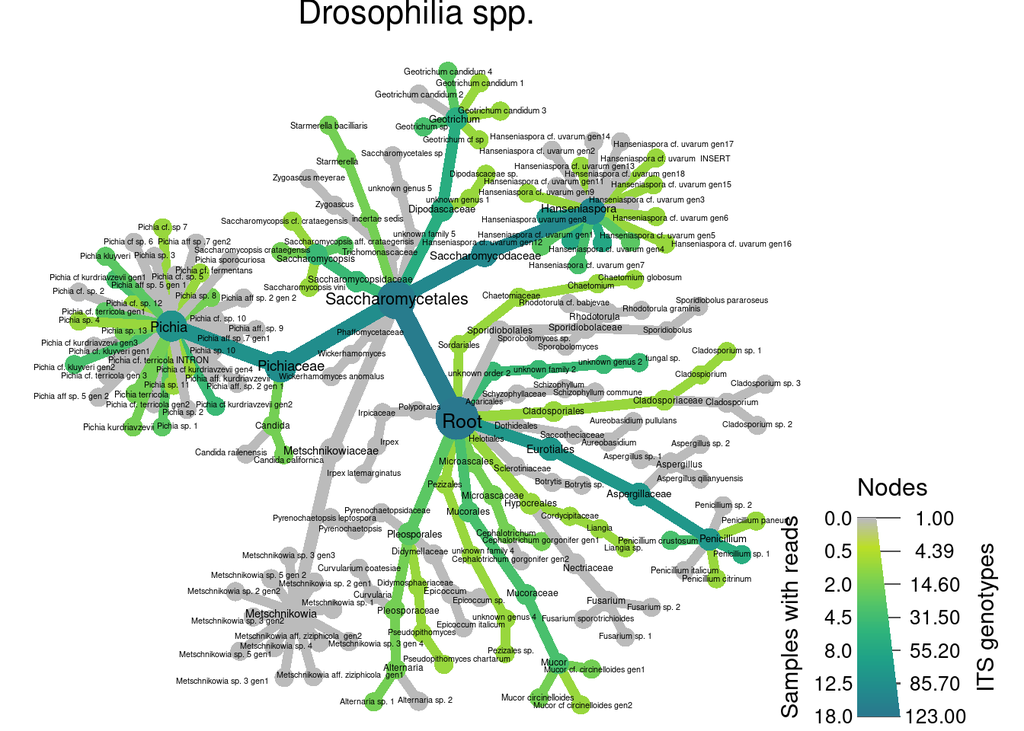

```r
  set.seed(1) # This makes the plot appear the same each time it is run
  heat_tree(obj,
            node_label = taxon_names,
            node_size = n_obs,
            node_color = insect,
            title = 'Drosophilia spp.',
            title_size = 0.04,
            node_size_axis_label = "ITS genotypes",
            node_color_axis_label = "Samples with reads",
            layout = "davidson-harel", # The primary layout algorithm
            initial_layout = "reingold-tilford",
            output_file = paste0("Figures/heat_tree_insect_ownscale", ext))
```

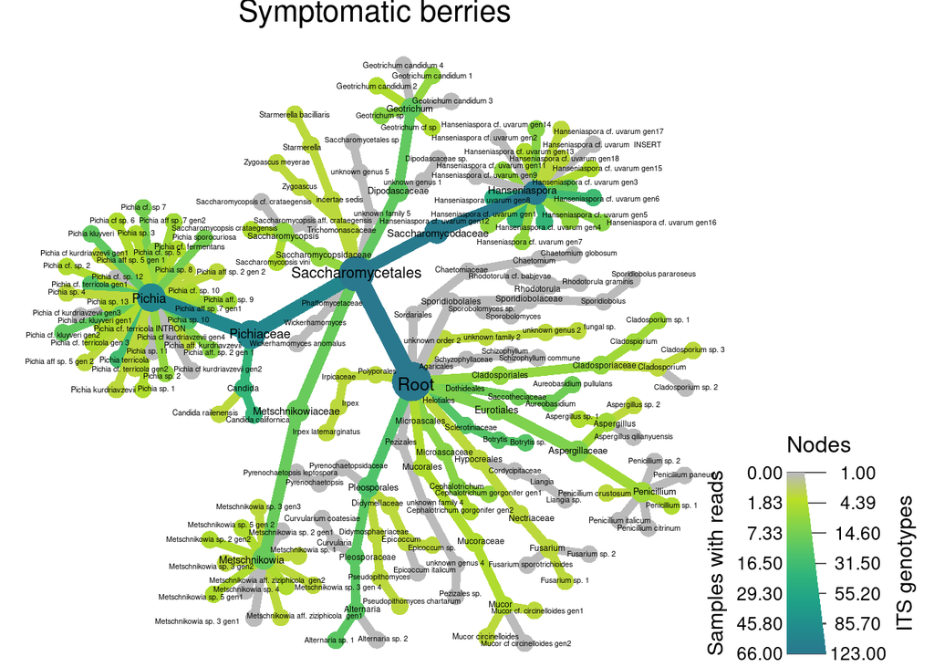

```r
  set.seed(1) # This makes the plot appear the same each time it is run
  heat_tree(obj,
            node_label = taxon_names,
            node_size = n_obs,
            node_color = obj$data$tax_occ$`sour rot`,
            title = "Symptomatic berries",
            title_size = 0.04,
            node_size_axis_label = "ITS genotypes",
            node_color_axis_label = "Samples with reads",
            layout = "davidson-harel", # The primary layout algorithm
            initial_layout = "reingold-tilford",
            output_file = paste0("Figures/heat_tree_sour_rot_ownscale", ext))
```

#### Relative abundance

As already mentioned, since samples are intrisically imbalanced, a direct comparion is not well suited. We thus resort to a relative abundance: for each sample, the proportion of counts are computed for each taxon.

```r
obj$data$its_table <- calc_obs_props(obj, data = "tax_data", cols = vars) # for proportion
obj$data$tax_table <- calc_taxon_abund(obj, data = "its_table", cols = vars)
# to compare differences between groups and then plot it
obj$data$diff_table <- compare_groups(obj, data = "tax_table", cols = vars, groups = types)
obj <- mutate_obs(obj, "diff_table",
                  wilcox_p_value = p.adjust(wilcox_p_value, method = "fdr"))

obj$data$diff_table$log2_median_ratio[obj$data$diff_table$wilcox_p_value > 0.05] <- 0
obj$data$diff_table$median_diff[obj$data$diff_table$wilcox_p_value > 0.05] <- 0
```

Note that we have only kept the differences that were significant, the other ones being set to 0. More precisely, we use a Mann-Whitney test, with an adjustment for multiple testing based on the *Benjamini-Hochberg* procedure (R function `p.adjust(method = "fdr")`).

Now, it is possible to compare the groups pairwise in terms of proportion within each group (healthy berries, sour rot symptomatic berries and Drosophilia), which all are on the same scale, namely the interval $[0,1]$. For each edge (i.e. taxon), the median of the proportion of the corresponding taxon in the group considered is computed. Then, in the first plot, the log (in base 2) of the ratio of the two medians (or equivalently, of the differences of the logs) is represented on the color scale, for each pair of groups. Note that, by convention, if any of the two medians is 0, then 0 is displayed. In the second plot, the difference between the two median proportion is plotted. Since the two medians both are in the interval $[0,1]$, the difference is in the interval $[-1,1]$.

A taxon colored blue is more abundant in the group in the column while a taxon colored orange is more abundant in group of the row; see also the color of the labels of rows and columns. See this [paragraph](https://grunwaldlab.github.io/metacoder_documentation/faq.html#differential-heat-trees-with-compare_groups-which-color-is-which-treatment) for implementation details and further clarifications about differential heat trees implemented in `metacoder`.

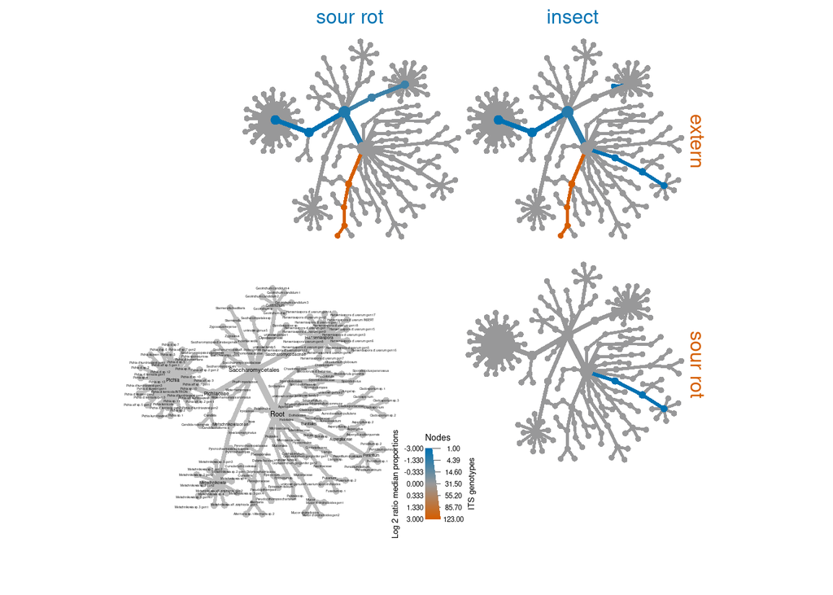

```r
custom_cols <- palette.colors()[c(6, 9, 7)] # subset of the Okabe-Ito palette
set.seed(1)
heat_tree_matrix(obj,
                 data = "diff_table",
                 node_size = n_obs, # n_obs is a function that calculates, in this case, the number of OTUs per taxon
                 node_label = taxon_names,
                 node_color = log2_median_ratio, # A column from `obj$data$diff_table`
                 node_color_range = custom_cols, # palette different
                 row_label_color = custom_cols[length(custom_cols)],
                 col_label_color = custom_cols[1],
                 node_color_trans = "area", # The default is scaled by circle area
                 node_color_interval = c(-3, 3), # The range of `log2_median_ratio` to display
                 edge_color_interval = c(-3, 3), # The range of `log2_median_ratio` to display
                 node_size_axis_label = "ITS genotypes",
                 node_color_axis_label = "Log 2 ratio median proportions",
                 layout = "davidson-harel", # The primary layout algorithm
                 initial_layout = "reingold-tilford", # The layout algorithm that initializes node locations
                 output_file = paste0("Figures/relative_log2_differential_heat_tree", ext))
```

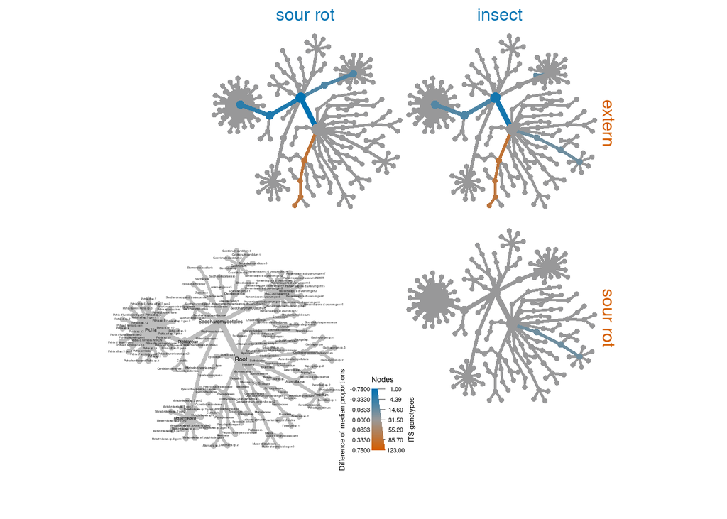

```r
heat_tree_matrix(obj,
                 data = "diff_table",
                 node_size = n_obs, # n_obs is a function that calculates, in this case, the number of OTUs per taxon
                 node_label = taxon_names,
                 node_color = median_diff, # A column from `obj$data$diff_table`
                 node_color_range = custom_cols, # palette different
                 row_label_color = custom_cols[length(custom_cols)],
                 col_label_color = custom_cols[1],
                 node_color_interval = c(-0.75, 0.75), # The range of `median_ratio` to display
                 edge_color_interval = c(-0.75, 0.75), # The range of `median_ratio` to display
                 node_size_axis_label = "ITS genotypes",
                 node_color_axis_label = "Difference of median proportions",
                 layout = "davidson-harel", # The primary layout algorithm
                 initial_layout = "reingold-tilford",
                 output_file = paste0("Figures/relative_median_differential_heat_tree", ext))
```

We also display the resulting $p-$values associated with all the taxon with significant differences in the various modalities.

```r
names_taxon <-  obj$data$class_data |> select(taxon_id, tax_name, tax_rank) |> distinct()
obj$data$diff_table |>
    filter(wilcox_p_value < 0.05 & !is.na(wilcox_p_value) ) |>
    select(taxon_id, treatment_1, treatment_2, wilcox_p_value, median_diff) |>
    filter(median_diff != 0 ) |>
    left_join(names_taxon, by = "taxon_id") |>
    select(- taxon_id, - tax_rank) |>
    relocate(tax_name, treatment_1, treatment_2) |>
    rename("Taxon name" = tax_name, "Modality 1 (row)" =  treatment_1, "Modality 2 (col)" =  treatment_2, "p-val." = wilcox_p_value , "median differences" = median_diff) |>
    knitr::kable()
```

| Taxon name | Modality 1 (row) | Modality 2 (col) | p-val. | median differences |
| --- | --- | --- | --- | --- |
| Pleosporales | extern | sour rot | 0.0000000 | 0.3095238 |
| Saccharomycetales | extern | sour rot | 0.0000000 | -0.7333333 |
| Pleosporaceae | extern | sour rot | 0.0000000 | 0.2857143 |
| Pichiaceae | extern | sour rot | 0.0000000 | -0.4807692 |
| Saccharomycodaceae | extern | sour rot | 0.0019866 | -0.1785714 |
| Alternaria | extern | sour rot | 0.0000000 | 0.2678571 |
| Pichia | extern | sour rot | 0.0000003 | -0.3798077 |
| Hanseniaspora | extern | sour rot | 0.0019866 | -0.1785714 |
| Alternaria sp. 1 | extern | sour rot | 0.0000000 | 0.2678571 |
| Eurotiales | extern | insect | 0.0010888 | -0.0555556 |
| Pleosporales | extern | insect | 0.0000507 | 0.3095238 |
| Saccharomycetales | extern | insect | 0.0008946 | -0.5718750 |
| Aspergillaceae | extern | insect | 0.0010888 | -0.0555556 |
| Pleosporaceae | extern | insect | 0.0000459 | 0.2857143 |
| Pichiaceae | extern | insect | 0.0028174 | -0.1885965 |
| Penicillium | extern | insect | 0.0002245 | -0.0555556 |
| Alternaria | extern | insect | 0.0000459 | 0.2678571 |
| Pichia | extern | insect | 0.0095754 | -0.1500000 |
| Alternaria sp. 1 | extern | insect | 0.0000459 | 0.2678571 |
| Hanseniaspora uvarum gen8 | extern | insect | 0.0066857 | -0.0900735 |
| Eurotiales | sour rot | insect | 0.0001634 | -0.0555556 |
| Aspergillaceae | sour rot | insect | 0.0001634 | -0.0555556 |
| Penicillium | sour rot | insect | 0.0000021 | -0.0555556 |